# Purpose Financial Data Challenge: Predicting Customer Default

### **Problem:**

We are tasked with developing a model to predict which customers will default on a loan based on a given set of features. Thus, we have a binary classification task of determining default (1) or no default (0).

### **Summary of results**

**Evaluation metric:** Our evaluation of the models was based primarily on **recall**. This metric was chosen for two main reasons: a) the class imbalance in the data and b) the greater costs of a false negative than a false positive. The class imbalance (reason a) eliminates metrics such as accuracy or area under the curve of the ROC curve. Reason b motivates a focus on recall over precision or F1 score (which balances recall and precision). To expand on the second point, the maximum cost of a false positive (deny a loan to someone who would not default) is the potential profit made on the loan. In contrast, the maximum cost of a false negative (someone who will default is approved for a loan) is the lost potential profit + the loan amount. Thus a greater emphasis is placed on recall.

**Model Selection:** Of the two models considered, we find that the XGboost classifier performs better with a recall of ~78% compared to ~72% for the logistic regression model. While the logistic regression model benefits from greater simplicity and explainability, the XGBoost model decisions can be sufficiently interpreted by feature importances and SHAP values. In either model the most important features are the customers monthly income and the average of the provided scores.

Therefore our recommended model is the **XGBoost classifier model with ~78% recall**

This notebook explores the dataset and the methodology used to construct the models. We conclude with some brief discussion of further analysis steps that could improve the model performance. Chief among these is development of an evaluation metric that quantitatively incorporates the emphasis on recall based on business constraints. One example is and $F{\beta}$ score where $\beta$ is determined by the expected profits and losses of loans.

```python
from google.colab import drive
drive.mount('/content/gdrive')
```

```python
# Data and math operations
import pandas as pd
import numpy as np
from scipy import stats
import copy

# Data visualizationa
import matplotlib.pyplot as plt
import seaborn as sns

# Model building
from sklearn import preprocessing
import xgboost as xgb
from sklearn.linear_model import LogisticRegression


# Model evaluation and interpretation
from sklearn.model_selection import train_test_split
from sklearn.metrics import roc_auc_score,  f1_score, recall_score, precision_score
from sklearn.metrics import roc_curve, precision_recall_curve, auc
from sklearn.model_selection import KFold,  cross_val_score # for validation of the model
from sklearn.metrics import classification_report, confusion_matrix, ConfusionMatrixDisplay



!pip install shap
import shap

# Hyperparameter Tuning
from hyperopt import hp, fmin, tpe, STATUS_OK, Trials
```

```
     ━━━━━━━━━━━━━━━━━━━━━━━━━━━━━━━━━━━━━━━━ 533.5/533.5 kB 5.4 MB/s eta 0:00:00
```

```python
data_path = '/content/gdrive/MyDrive/0_Career/Purpose Financial/Purpose Financial Data Challenge 2024/'
df = pd.read_csv(data_path + 'train.csv')
```

```python
df.columns
```

```
Index(['id', 'date_of_birth', 'number_dependants', 'credit_utilization',
       'debt_to_income_ratio', 'monthly_income', 'number_open_credit_lines',
       'number_open_loans', 'number_90_days_past_due', 'number_charged_off',
       'score1', 'score2', 'target'],
      dtype='object')
```

```python
df.info()
```

```
<class 'pandas.core.frame.DataFrame'>
RangeIndex: 20839 entries, 0 to 20838
Data columns (total 13 columns):
 #   Column                    Non-Null Count  Dtype
---  ------                    --------------  -----
 0   id                        20839 non-null  int64
 1   date_of_birth             20839 non-null  object
 2   number_dependants         20839 non-null  int64
 3   credit_utilization        20839 non-null  float64
 4   debt_to_income_ratio      20839 non-null  float64
 5   monthly_income            20839 non-null  int64
 6   number_open_credit_lines  20839 non-null  int64
 7   number_open_loans         20839 non-null  int64
 8   number_90_days_past_due   20839 non-null  int64
 9   number_charged_off        20839 non-null  int64
 10  score1                    20839 non-null  int64
 11  score2                    20839 non-null  int64
 12  target                    20839 non-null  int64
dtypes: float64(2), int64(10), object(1)
memory usage: 2.1+ MB
```

```python
df.duplicated().sum()
```

```
0
```

```python
df.describe()
```

|  | id | number_dependants | credit_utilization | debt_to_income_ratio | monthly_income | number_open_credit_lines | number_open_loans | number_90_days_past_due | number_charged_off | score1 | score2 | target |
| --- | --- | --- | --- | --- | --- | --- | --- | --- | --- | --- | --- | --- |
| count | 20839.000000 | 20839.000000 | 2.083900e+04 | 20839.000000 | 20839.000000 | 20839.000000 | 20839.000000 | 20839.000000 | 20839.000000 | 20839.000000 | 20839.00000 | 20839.000000 |
| mean | 10923.946878 | 0.483421 | 4.815929e-02 | 0.333507 | 2290.772110 | 4.997745 | 2.027497 | 0.098901 | 0.098901 | 669.511637 | 669.29440 | 0.102164 |
| std | 6295.585008 | 0.719653 | 4.571744e-02 | 0.117332 | 320.090288 | 2.248021 | 1.431671 | 0.314963 | 0.315420 | 98.005767 | 98.60763 | 0.302871 |
| min | 1.000000 | -1.000000 | 3.932283e-07 | 0.029386 | 2000.000000 | 0.000000 | 0.000000 | 0.000000 | 0.000000 | 500.000000 | 500.00000 | 0.000000 |
| 25% | 5482.000000 | 0.000000 | 1.436676e-02 | 0.247782 | 2100.000000 | 3.000000 | 1.000000 | 0.000000 | 0.000000 | 584.000000 | 583.00000 | 0.000000 |
| 50% | 10929.000000 | 0.000000 | 3.478343e-02 | 0.325432 | 2200.000000 | 5.000000 | 2.000000 | 0.000000 | 0.000000 | 669.000000 | 670.00000 | 0.000000 |
| 75% | 16366.500000 | 1.000000 | 6.789546e-02 | 0.411210 | 2400.000000 | 6.000000 | 3.000000 | 0.000000 | 0.000000 | 755.000000 | 754.00000 | 0.000000 |
| max | 21839.000000 | 6.000000 | 5.387018e-01 | 0.801838 | 5000.000000 | 15.000000 | 9.000000 | 3.000000 | 3.000000 | 839.000000 | 839.00000 | 1.000000 |

```python
df.head()
```

|  | id | date_of_birth | number_dependants | credit_utilization | debt_to_income_ratio | monthly_income | number_open_credit_lines | number_open_loans | number_90_days_past_due | number_charged_off | score1 | score2 | target |
| --- | --- | --- | --- | --- | --- | --- | --- | --- | --- | --- | --- | --- | --- |
| 0 | 1 | 1993-03-14 | 1 | 0.036495 | 0.208897 | 2400 | 6 | 2 | 0 | 0 | 570 | 817 | 0 |
| 1 | 2 | 1966-09-27 | 1 | 0.023423 | 0.260438 | 2200 | 6 | 1 | 0 | 0 | 741 | 756 | 0 |
| 2 | 3 | 1931-01-11 | 2 | 0.027205 | 0.335922 | 3000 | 6 | 1 | 0 | 1 | 805 | 779 | 0 |
| 3 | 4 | 1953-01-07 | 1 | 0.009141 | 0.353779 | 2100 | 2 | 4 | 0 | 0 | 573 | 829 | 0 |
| 4 | 5 | 1943-11-17 | 0 | 0.068424 | 0.314966 | 2500 | 2 | 3 | 0 | 0 | 833 | 629 | 0 |

```python
#unbalanced dataset
df['target'].value_counts(normalize=True)
df['target'].value_counts()
```

```
0    18710
1     2129
Name: target, dtype: int64
```

## Exploratory Data Analysis (EDA)

From a quick look at our data, we see a few important characteristics:

- No null values and no duplicate records. This makes cleaning much easier
- **Imbalanced dataset.** There is a 9/1 ratio between the majority class and the minority, with the minority being the target variable. the imbalance in the data is seemingly inherent, as opposed to a shortcoming in the dataset or data acquisition. It seems reasonable that only ~10% of customers with loans default.
- All features (except date_of_birth) are numerical values with a mix of discrete and continuous. date_of_birth will be converted into numerical age.
- Summary statistics:
  - number_of_dependants goes negative, which seems problematic
  - score1 and score2 look like some version of credit score (~500-840)
  - max credit utilization is ~54% and debt_to_income ratio never exceeds 0.8.

Data dictionary:

```
 0   id                        : customer identifier
 1   date_of_birth             : DOB (YYY-MM-DD)
 2   number_dependants         : number of dependents
 3   credit_utilization        : percentage of available credit used
 4   debt_to_income_ratio      : self-explanatory
 5   monthly_income            : self-explanatory
 6   number_open_credit_lines  : self-explanatory
 7   number_open_loans         : self-explanatory
 8   number_90_days_past_due   : number of delinquent (i.e. 90+ days) loans
 9   number_charged_off        : loans/debts that have been written off as a loss by the lender
 10  score1                    : looks similar to a credit score similar to e.g.,  FICO, TransUnion, etc, but range of values is 500-839
 11  score2                    : another credit score with nearly identical distribution to score1
 12  target                    : whether defaulted (1) or not (0)
```

In the following cells we will explore the dataset in more depth.

### Age of customers

Before getting fully into EDA, it will be useful to convert DOB to age. Integer years should be sufficient. We calculate age and preview the results.

```python
# convert DOB -> Age [yrs]
df['age'] = (pd.to_datetime('now',utc=True) - pd.to_datetime(df['date_of_birth'],utc=True)).astype('timedelta64[Y]').astype('int')
df[['date_of_birth', 'age']].sort_values('date_of_birth')
```

|  | date_of_birth | age |
| --- | --- | --- |
| 422 | 1829-06-03 | 194 |
| 1714 | 1829-06-09 | 194 |
| 20259 | 1830-07-05 | 193 |
| 5192 | 1858-04-07 | 165 |
| 12348 | 1886-06-30 | 137 |
| ... | ... | ... |
| 9708 | 1999-05-16 | 24 |
| 18588 | 1999-05-17 | 24 |
| 1332 | 1999-05-18 | 24 |
| 6244 | 1999-05-20 | 24 |
| 10883 | 1999-05-22 | 24 |

20839 rows × 2 columns

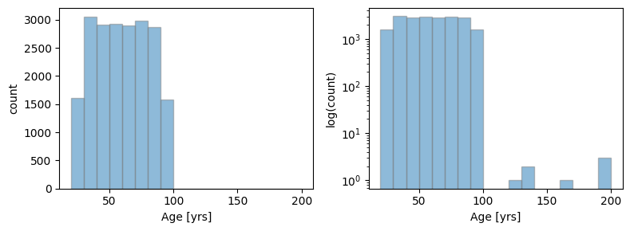

```python
bins = np.linspace(20, 200, 19)

fig, ax = plt.subplots(1,2, figsize = (8,3), dpi=100)

ax[0].hist(df['age'],bins=bins, edgecolor='grey', alpha=0.5)
ax[0].set_xlabel('Age [yrs]')
ax[0].set_ylabel('count')

ax[1].set_yscale('log')
ax[1].hist(df['age'],bins=bins, edgecolor='grey', alpha=0.5)
ax[1].set_xlabel('Age [yrs]')
ax[1].set_ylabel('log(count)')

plt.tight_layout()
```

With age as a new variable, it is easy to see some very strange data (not visible in a linear scale, see log scale on the right). Namely, that we have some customers that are over 100 years old and up to nearly 200 years old! Since we are given features such as date of birth and number of dependants, it is probably safe to assume that these customers are individual people vs corporations, so these extreme ages are not valid. Since the lowest extreme value (>95) is 127, these could potentially be simple keystroke errors (e.g. year input as 1896 instead of 1996). It could also potentially be indicative of fraud and could be flagged.

Also the lowest age is 24. Presumably there could be customers with loan history that are younger than 24, so we may want to keep this in mind, but it is not an obvious data problem.

We will need to address these extreme age values. Since there are only a few instances (7), we can set an age cutoff and remove the more extreme values from our data. A closer look at the distribution can motivate an appropriate age cutoff.

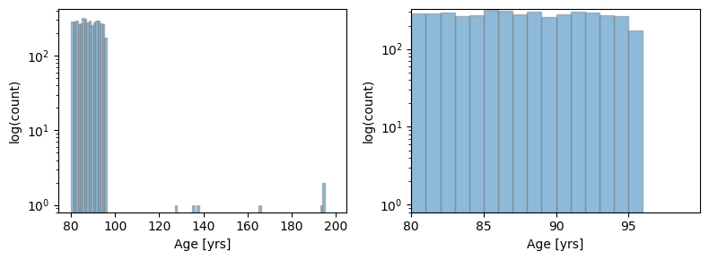

```python
age_cut = 80

bins = np.arange(age_cut, 200, 1)
bins2 = np.arange(age_cut, 100, 1)

fig, ax = plt.subplots(1,2, figsize = (8,3), dpi=100)

ax[0].set_yscale('log')
ax[0].hist(df[df['age']>=age_cut]['age'],bins=bins, edgecolor='grey', alpha=0.5)
ax[0].set_xlabel('Age [yrs]')
ax[0].set_ylabel('count')
ax[0].set_ylabel('log(count)')
ax[0].set_ylim(0.8)

ax[1].set_yscale('log')
ax[1].hist(df[df['age']>=age_cut]['age'],bins=bins2, edgecolor='grey', alpha=0.5)
ax[1].set_xlabel('Age [yrs]')
ax[1].set_ylabel('log(count)')
ax[1].set_xlim(age_cut)
ax[1].set_ylim(0.8)

plt.tight_layout()
```

We see that the distribution of ages is fairly consistent up until 95. Outliers are all well above 100. Since our distribution goes to 95 that will make a reasonable cutoff.

### Pairplot

The pairplot will give us a general overview of pairwise relationships between variables. For this dataset, we have ~20000 records and only 11 numerical features, so the pairplot on the full dataset should be manageable. If we wanted we could take a smaller sample of the data (e.g. 5000 random rows) to speed things up, or a smaller set of features if we had a larger feature set.

```python
%%time
sns.pairplot(df.drop(columns = ['id']), hue='target', corner=True)
```

```
Output hidden; open in https://colab.research.google.com to view.
```

My initial takeaways from this are that there are not obvious strong correlations between any parameters.

Some other notes:

**Scores:** Its somewhat surprising tha score1 and score2 values are not more correlated, however without actual knowledge of how these are defined we can not draw conclusions from the lack of correlation.

The distribution of each score feature for the target variable is slightly right skewed with a noticeable peak at lower values. Indeed, in the score1-score2 scatter plot we see that "defaults" are concentrated at low score values, while the high-score upper quadrant is dominated by non-"defaults".

**Monthly Income:** Aside from the scores, monthly income also appears to have "defaults" concentrated at low values, indicating there may be a relation where higher income -> less likely to default.

Taking a closer look at these parameters below emphasizes these observations.

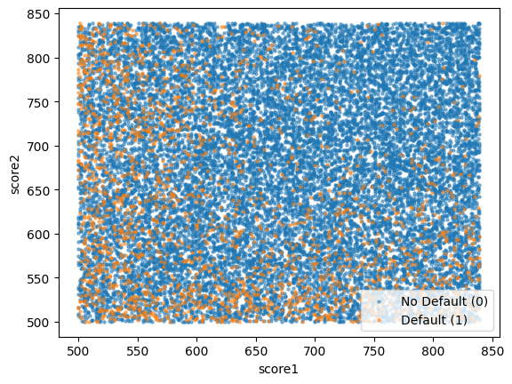

```python
plt.scatter(df['score1'][df['target']==0], df['score2'][df['target']==0], s=5, alpha=0.5, label = 'No Default (0)')
plt.scatter(df['score1'][df['target']==1], df['score2'][df['target']==1], s=5, alpha=0.5, label = 'Default (1)')
plt.legend()
plt.xlabel('score1')
plt.ylabel('score2')
```

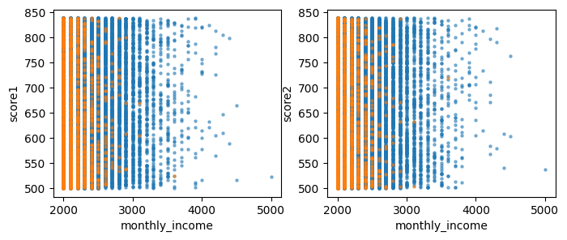

```python
fig, ax = plt.subplots(1,2, figsize=(8,3))
ax[0].scatter(df['monthly_income'][df['target']==0], df['score1'][df['target']==0], s=5, alpha=0.5, label='No Default (0)')
ax[0].scatter(df['monthly_income'][df['target']==1], df['score1'][df['target']==1], s=5, alpha=0.5, label='Default (1)')

ax[0].set_xlabel('monthly_income')
ax[0].set_ylabel('score1')


ax[1].scatter(df['monthly_income'][df['target']==0], df['score2'][df['target']==0], s=5, alpha=0.5, label='No Default (0)')
ax[1].scatter(df['monthly_income'][df['target']==1], df['score2'][df['target']==1], s=5, alpha=0.5, label='Default (1)')
ax[1].set_xlabel('monthly_income')
ax[1].set_ylabel('score2')
```

### Correlation Matrix

We can quantify the observations above by looking at the correlation matrix. Here we see some confirmation of our earlier statements. E.g., No correlation between individual features (including score1 and score2) and the monthly_income and individual scores are weakly anti-correlated with the target variable.

Thus far, we have some strong motivations that income and scores will be our most important parameters in the analysis.

```
The default value of numeric_only in DataFrame.corr is deprecated. In a future version, it will default to False. Select only valid columns or specify the value of numeric_only to silence this warning.
```

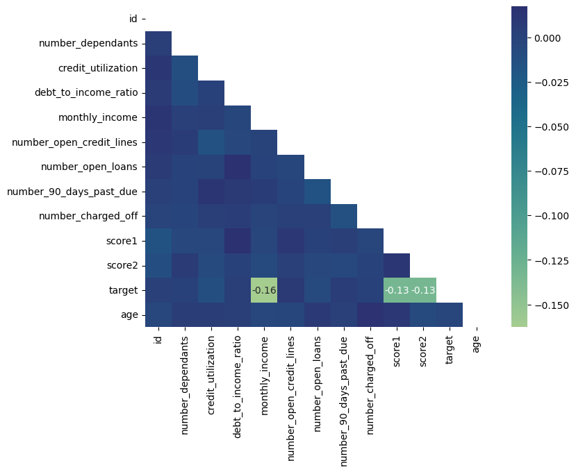

```python
corr = df.corr()

trimask = np.triu(np.ones_like(corr, dtype=bool))

# Create a heatmap to visualize how correlated variables are
plt.figure(figsize=(8, 6))
ax = plt.gca()

sns.heatmap(corr,
    annot=True,
    cmap="crest", mask=trimask,ax=ax)

# this block will only add annotations for correlations with magnitude >0.1
for t in ax.texts:
    if abs(float(t.get_text()))>=0.1:
        t.set_text(t.get_text())
    else:
        t.set_text("")
```

### Bars and histograms

For the time being we will focus only on how default/no default classification affects the distributions of the individual features. However in an expanded analysis we could investigate similar relations between different features, e.g. bin monthly income and see how number of loans changes for low, middle and high income.

**Bar charts of discrete features**

The next several plots show barcharts for our discrete numerical features, divided into the two target classes. What we are looking for here are values of any discrete variables that deviate substantially from the 90/10 target class ratio.

One option could be to bin some of these values, to gain higher counts at some of the extremes that may yield some predictive power. For now we will continue as is.

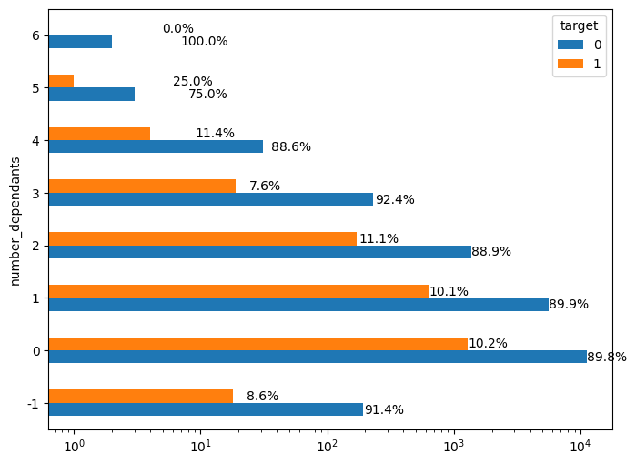

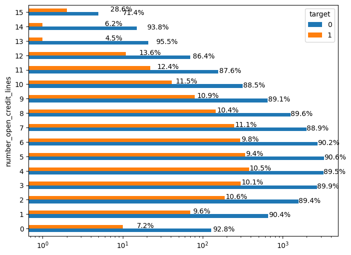

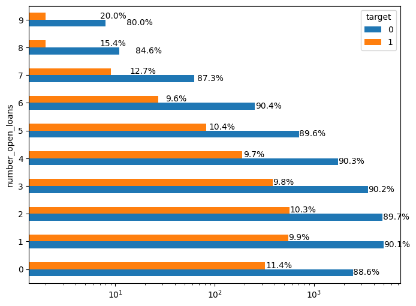

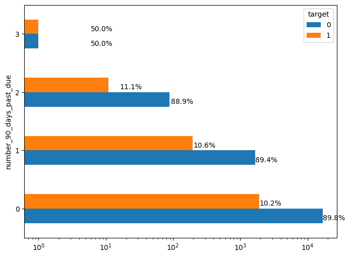

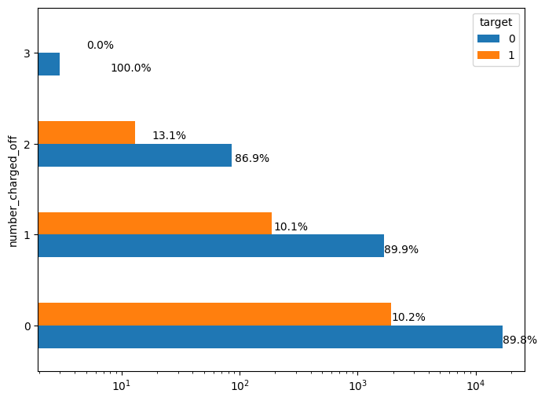

```python
# columns with discrete values
discrete_cols = [ 'number_dependants', 'number_open_credit_lines',
       'number_open_loans', 'number_90_days_past_due', 'number_charged_off']


target_var='target'

annotate=True
data=df
for col in discrete_cols:
    fig, ax = plt.subplots(1, 1, figsize=(8,6))
    ax.set_xscale('log')
    gb = df.groupby([col, target_var])[target_var]
    gb.count().unstack().plot(kind='barh', legend=True, ax=ax)
    for c, container in enumerate(ax.containers):

        for i, p in enumerate(container):
            group_total = ax.containers[0][i].get_width() + ax.containers[1][i].get_width()

            width = p.get_width()
            height = p.get_height()
            x, y = p.get_xy()

            if annotate:
                ax.annotate('{:.1f}%'.format(100*width/group_total), (x +width + 5, i + (c-1)*0.25  + 0.05), ha='left')

    print('\n')
```

**Histograms of Continuous Features**

This next code block will simply provide a closer look at the distributions of the continuous variables which is already shown in the pairplot as KDEs. However, we will use normalized histograms to make the relative distribution trends more pronounced.

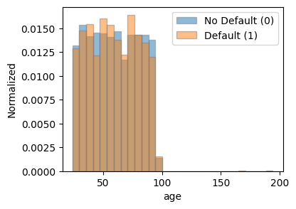

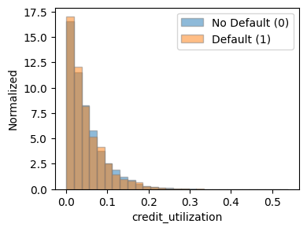

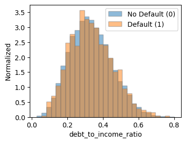

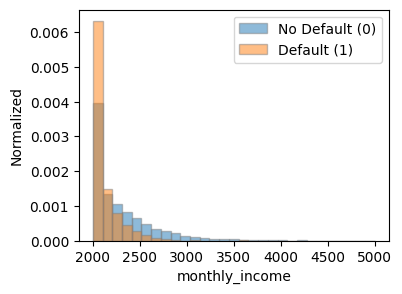

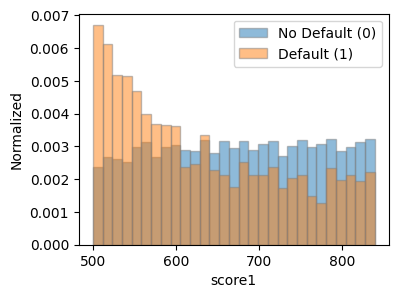

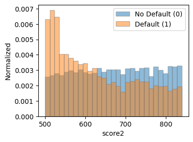

```python
#list of contniuous numerical columns
continuous_cols = [  'age', 'credit_utilization',
       'debt_to_income_ratio', 'monthly_income',
       'score1', 'score2']

target_var='target'


data=df
for col in continuous_cols:
    fig, ax = plt.subplots(1, 1, figsize=(4,3))


    bins = np.linspace(np.nanmin(data[col]), np.nanmax(data[col]), 30)

    ax.hist(data[data[target_var]==0][col], label='No Default (0)', bins=bins, alpha=0.5, edgecolor='grey', density=True)
    ax.hist(data[data[target_var]==1][col], label='Default (1)', bins=bins, alpha=0.5, edgecolor='grey', density=True)
    ax.legend()
    ax.set_xlabel(col)
    ax.set_ylabel('Normalized')
```

In the plots above we can see that the normalized distributions for most parameters are pretty similar. However, we again identify features that seem to have some distinguishing power between the target class. Specifically, both scores (score1 and score2) have an increased default rate at low values in comparison to the no default category. We see this as well with monthly income, in particular for the lowest income bin. This is consistent with the pairplot and correlation matrix results.

Again, we can anticipate that these are likely to have some predictive power. In the next cells we can look into transformations of these parameters that may provide additional predictive power to our model.

```
KstestResult(statistic=0.20689655172413793, pvalue=0.5721774392909802, statistic_location=0.000646714231755061, statistic_sign=1)
```

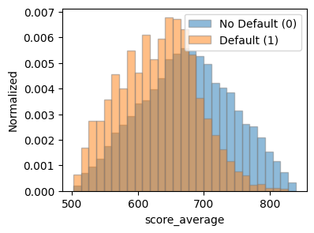

```python
# A simple average of the two score values


data=copy.deepcopy(df) # make a copy so that we dont affect our actual data

data['score_average'] = (data['score1'] + data['score2'])/2
col = 'score_average'
fig, ax = plt.subplots(1, 1, figsize=(4,3))


df1 = data[data[target_var]==1][col]
df0 = data[data[target_var]==0][col]

bins = np.linspace(np.nanmin(data[col]), np.nanmax(data[col]), 30)

hist2 = ax.hist(df0, label='No Default (0)', bins=bins, alpha=0.5, edgecolor='grey', density=True)[0]
hist1 = ax.hist(df1, label='Default (1)', bins=bins, alpha=0.5, edgecolor='grey', density=True)[0]
ax.legend()
ax.set_xlabel(col)
ax.set_ylabel('Normalized')

# compare normalized distributions with Kolmogorov-Smirnov 2 sample test
# Note this is only used for comparing how discriminative differnt feature
# may be relative to one another (e.g. score_average vs score_income_multiplier)
# It is not being used for intepreting the actual staistical significances
stats.ks_2samp(hist1, hist2)
```

The average of the scores provides two fairly distinct, somewhat Gaussian distributions for the two target classes. This indicates that there may be predictive power here.

```
KstestResult(statistic=0.4827586206896552, pvalue=0.0019790709048350735, statistic_location=0.0, statistic_sign=1)
```

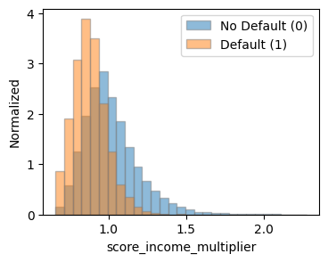

```python
''' Here we try multiplying the two categories (score and income) that look to potentially
 have some predictive power, and normalize by the mean of each feature.'''

data=copy.deepcopy(df) # make a copy so that we dont affect our actual data

data['score_average'] = (data['score1'] + data['score2'])/2
data['score_income_multiplier'] = data['score_average']/data['score_average'].mean() * data['monthly_income']/data['monthly_income'].mean()

col = 'score_income_multiplier'
fig, ax = plt.subplots(1, 1, figsize=(4,3))


df1 = data[data[target_var]==1][col]
df0 = data[data[target_var]==0][col]


bins = np.linspace(np.nanmin(data[col]), np.nanmax(data[col]), 30)

hist2 = ax.hist(df0, label='No Default (0)', bins=bins, alpha=0.5, edgecolor='grey', density=True)[0]
hist1 = ax.hist(df1, label='Default (1)', bins=bins, alpha=0.5, edgecolor='grey', density=True)[0]
ax.legend()
ax.set_xlabel(col)
ax.set_ylabel('Normalized')


# compare normalized distributions with Kolmogorov-Smirnov 2 sample test
stats.ks_2samp(hist1, hist2)
```

## Data Cleaning, Feature Engineering, and Feature selection

#### **Data cleaning:**

We have identified at least two instances of problematic data:

- Extreme Age outliers (e.g. >~95).
- Negative number of dependants

For both groups, the summary statistics for these subsets are consistent with the total sample, so do not indicate that they are particularly unique aside form these data issues.

To address these, we will remove any records with age >95 and we will set all negative values for number of dependants to 0.

#### **Feature Engineering:**

Already we have created one new feature, which is age. We will also create a few new features based on the EDA, in particular relating to score and income features. The new parameters are:

- age
- score_average : average of score1 and score2
- score_income_multiplier : defined as score_average/mean(score_average) * monthly_income/mean(monthly_income). This is essentially a score-income interaction term

There are many other features that could potentially be created. These could include more direct relation between features, e.g. 'debt' as the product of the debt_to_income_ratio and monthly_income, or 'credit' as the credit_utilization divided by debt. As mentioned earlier, we could also try binning features. For instance, grouping high values of open credit lines into one bin rather than having numerous values with only a few instances.

In some earlier test I incorporated some additional features, but ultimately they were often highly correlated (e.g. debt and debt_to_income_ratio) and/or uniformative, so Ive not included them here.

```python
def data_preprocess(df):

    '''
        Perform data preprocessing on an input dataframe.
        Checks for null and duplicates, adds new features,
        removes records with ages >95 and sets negative_dependants values to 0.
        No columns are removed in this stage (e.g. date_of_birth)
    '''

    # Check nulls and duplicates
    num_nulls = df.isnull().sum().sum()
    num_duplicates = df.duplicated().sum()
    if num_nulls != 0:
        print("Warning: {} null values".format(num_nulls))

    if num_duplicates != 0:
        print("Warning: {} duplicate rows".format(num_duplicates))

    # new features
    df['age'] = (pd.to_datetime('now',utc=True) - pd.to_datetime(df['date_of_birth'],utc=True)).astype('timedelta64[Y]').astype('int')
    df['score_average'] = (df['score1'] + df['score2'])/2
    # product of mean normalized score average and monthly income
    df['score_income_multiplier'] = df['score_average']/df['score_average'].mean() * df['monthly_income']/df['monthly_income'].mean()

    # Remove records with Age above designated upper limit
    if len(df[df['age']>95]) != 0:
        print('{} records exceeds upper age limit'.format(len(df[df['age']>95])))
    df = df[df['age']<=95]

    # we do not have a lower age cutoff, but it would be good to get a warning
    # if we have some anomalous lower age values,
    # esp. e.g. something like 5 years that would not make sense
    if len(df[df['age']<24]) != 0:
        print('{} records exceeds lower age limit (min {})'.format(len(df[df['age']<24]), df[df['age']<24]['age'].min()))

    # Set negative dpendant values to 0
    if len(df[df['number_dependants']<0] != 0):
        print('{} rows with negative dependants, setting equal to 0 (min {})'.format(len(df[df['number_dependants']<0] != 0), df['number_dependants'].min()))
    df.loc[df['number_dependants']==-1, 'number_dependants'] = 0

    return df
```

```python
df = pd.read_csv(data_path + 'train.csv')

df = data_preprocess(df)
```

```
7 records exceeds upper age limit
209 rows with negative dependants, setting equal to 0 (min -1)
```

### Feature Selection

Generally our feature selection will be fairly straightforward. In all models we will remove the **id** and **date_of_birth** features, since id is uninformative and any relevant information from the DOB is encapsulated in age.

We have also identified income and score features as being the most promising predictors, so our feature selection will always involve these characteristics.

To get more detailed, we will review the correlation matrix with new features added

```
The default value of numeric_only in DataFrame.corr is deprecated. In a future version, it will default to False. Select only valid columns or specify the value of numeric_only to silence this warning.
```

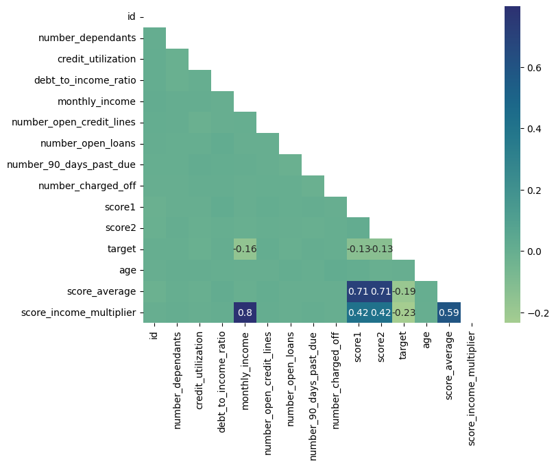

```python
new_feats = []

corr = df.corr()

trimask = np.triu(np.ones_like(corr, dtype=bool))

# Create a heatmap to visualize how correlated variables are
plt.figure(figsize=(8, 6))
ax = plt.gca()
sns.heatmap(corr,
    annot=True,
    cmap="crest", mask=trimask,ax=ax)


for t in ax.texts:
    if abs(float(t.get_text()))>=0.1:
        t.set_text(t.get_text()) #if the value is greater than 0.4 then I set the text
    else:
        t.set_text("") # if not it sets an empty text
```

Unsurprisingly, several of the new features are correlated to one another since they are mostly sums and products of other features. Two of the new features, score_average and score_income multiplier are slightly more (anti) correlated to the target. While not significant correlations, they may help contribute some predictive power.

The top features by correlation to the Target are score_income_multiplier, score_average, and monthly_income. While score_income_multiplier is the most correlated to the target, it is still pretty weak. Furthermore, this feature is highly correlated to the monthly_income and score_average. Its unlikely that this feature will add much that is not already provided by the income and score features.

On the other hand, score_average and monthly_income are not correlated, and both have some correlation to the target however weak.

Therefore, our focus will be on these two features. We will however test how other features affect the results.

## Modeling

The models we'll employ in this analysis are a logistic regression classifier and a gradient boosted decision tree model with XGBoost.

The first model we will try is a very simple logistic regression model which will serve as our baseline.

For this problem, since we have a pretty heavily imbalanced dataset our model accuracy will not be a suitable evaluation metric. An F1 score or area under the precision recall curve would be more appropriate, as they provide a balance of precision and recall.

However, for this problem a simple balance of precision and recall is not ideal. Really, we are more concerned with recall than precision. This is because a False Negative is more costly than a False Positive.

A false positive means we likely deny a loan to someone who would not default, and thus lose out on potential profit. However, a false negative means we may approve a loan to someone who defaults, thus losing the outstanding loan balance + potential profit. Thus we want our models to prioritize recall more than precision.

#### Train-Test-Split

```python
### Train-test-split

def get_train_test_dict(df, target_var,id_col=None, cols=[], drop=True):
    '''
        utility to easily get the train and test datasets stored in a dictionary.
        columns chosen by cols can be kept or dropped. If an id col is included
        the values of that column will also be included in the dictionary
    '''
    fit_df = copy.deepcopy(df)



    if id_col != None:
        try:
            cols.remove(id_col)
            print('remove id_col')
        except:
            print('id col not in cols')


    if drop:
        if target_var not in cols:
            cols.append(target_var)
        X, y = fit_df.drop(columns=drop_train_cols), fit_df[target_var]
    else:
        if id_col !=None:
            X, y = fit_df[cols+[id_col]], fit_df[target_var]
        else:
            X, y = fit_df[cols], fit_df[target_var]


    X_train, X_test, y_train, y_test = train_test_split(X, y, test_size=0.3, random_state=0)

    if id_col!=None:
        train_id = X_train[id_col].to_list()
        test_id = X_test[id_col].to_list()

        X_train.drop(columns=[id_col], inplace=True)
        X_test.drop(columns=[id_col], inplace=True)
    else:
        train_id = 'No id column provided'
        test_id = 'No id column provided'




    evalset = [(X_train, y_train), (X_test,y_test)]

    tts_dict = {'X':X,
                'y':y,
                'X_train':X_train,
                'y_train':y_train,
                'X_test':X_test,
                'y_test':y_test,
                'eval_set':evalset,
                'train_ids':train_id,
                'test_ids':test_id}

    return tts_dict
```

## Logistic Regression

An important point in our model is that in order to account for the class imbalance, we apply a class weighting in the logistic regression. Here this is done by setting the class_weight parameter to "balanced". We will later explore how this weighting can affect our results

```python
seed=0
target_var  =  'target'

# These columns will be dropped from the training data
keep_train_cols = ['monthly_income', 'score_average']



lr_base_dict = get_train_test_dict(df, target_var, id_col = 'id', cols=keep_train_cols, drop=False)
lr_base_dict['X_train']
```

```
id col not in cols
```

|  | monthly_income | score_average |
| --- | --- | --- |
| 6342 | 2000 | 709.0 |
| 977 | 2700 | 556.5 |
| 11172 | 2300 | 795.5 |
| 6934 | 2100 | 553.5 |
| 8903 | 2000 | 777.5 |
| ... | ... | ... |
| 13128 | 2000 | 702.0 |
| 19654 | 2000 | 747.5 |
| 9849 | 2000 | 762.0 |
| 10803 | 2500 | 598.0 |
| 2734 | 2600 | 648.0 |

14582 rows × 2 columns

```python
lr_base_model = LogisticRegression(random_state=0,  class_weight = 'balanced')

print('features:', lr_base_dict['X_train'].columns.to_list())

# scale training data
scaler = preprocessing.StandardScaler().fit(lr_base_dict['X_train'])

X_train_scaled = pd.DataFrame(scaler.transform(lr_base_dict['X_train']), columns=lr_base_dict['X_train'].columns)
X_test_scaled = pd.DataFrame(scaler.transform(lr_base_dict['X_test']), columns=lr_base_dict['X_test'].columns)


# Fit (scaled) train data
lr_base_model.fit(X_train_scaled, lr_base_dict['y_train'])

# make predictions for (scaled) test data
lr_base_y_pred = lr_base_model.predict(X_test_scaled)
lr_base_y_proba = lr_base_model.predict_proba(X_test_scaled)


# evaluate predictions
pr_fpr, pr_tpr, pr_thresholds = precision_recall_curve(lr_base_dict['y_test'], lr_base_y_proba[:,1])
auc_pr = auc(pr_tpr, pr_fpr)


roc_fpr, roc_tpr, roc_thresholds = roc_curve(lr_base_dict['y_test'], lr_base_y_proba[:,1])
roc_auc = roc_auc_score(lr_base_dict['y_test'], lr_base_y_pred)
f1 = f1_score(lr_base_dict['y_test'], lr_base_y_pred)
recall = recall_score(lr_base_dict['y_test'], lr_base_y_pred)
precision = precision_score(lr_base_dict['y_test'], lr_base_y_pred)


print("roc_auc: %.2f%%" % (roc_auc * 100.0))
print("auc_pr: %.2f%%" % (auc_pr * 100.0))
print("Recall: {:.2f}%".format(recall * 100.0))
print("Precision: {:.2f}%".format(precision * 100.0))
print("F1: {:.2f}%".format(f1 * 100.0))

print(classification_report(lr_base_dict['y_test'], lr_base_y_pred))
```

```
features: ['monthly_income', 'score_average']
roc_auc: 68.43%
auc_pr: 23.14%
Recall: 72.05%
Precision: 19.04%
F1: 30.12%
              precision    recall  f1-score   support

           0       0.95      0.65      0.77      5606
           1       0.19      0.72      0.30       644

    accuracy                           0.66      6250
   macro avg       0.57      0.68      0.54      6250
weighted avg       0.87      0.66      0.72      6250
```

```python
kfold = KFold(n_splits=10, shuffle=True,random_state=seed)
results = cross_val_score(lr_base_model, X_train_scaled, lr_base_dict['y_train'],scoring='f1', cv=kfold)
print("K-fold f1 score: {:.2f}% ({:.2f}%)".format(results.mean()*100, results.std()*100))

results = cross_val_score(lr_base_model, X_train_scaled, lr_base_dict['y_train'],scoring='recall', cv=kfold)
print("K-fold recall score: {:.2f}% ({:.2f}%)".format(results.mean()*100, results.std()*100))

results = cross_val_score(lr_base_model, X_train_scaled, lr_base_dict['y_train'],scoring='precision', cv=kfold)
print("K-fold precision score: {:.2f}% ({:.2f}%)".format(results.mean()*100, results.std()*100))
```

```
K-fold f1 score: 30.46% (2.63%)
K-fold recall score: 72.41% (4.20%)
K-fold precision score: 19.32% (1.96%)
```

### Initial Results

As mentioned earlier, recall is our most important feature and has a value of ~72%. The precision, F1 and AUC-PR scores are pretty poor.

Other views of the evaluation are provided by looking directly at the precision-recall curve below or the confusion matrix. These simply illustrate that the model is fairly poor in terms of the F1, precision, and AUC-PR. However the recall results are decent.

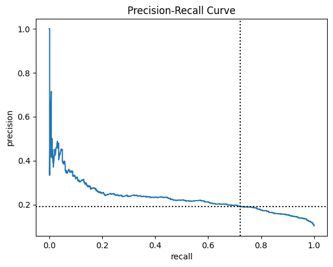

```python
idx = np.argmin(abs(pr_thresholds - 0.5))

plt.plot(pr_tpr, pr_fpr)

plt.axvline(pr_tpr[idx], ls=':', color='k', label='Probability Threshold')
plt.axhline(pr_fpr[idx], ls=':', color='k')
plt.xlabel('recall')
plt.ylabel('precision')
plt.title('Precision-Recall Curve')
```

```
              precision    recall  f1-score   support

           0       0.95      0.65      0.77      5606
           1       0.19      0.72      0.30       644

    accuracy                           0.66      6250
   macro avg       0.57      0.68      0.54      6250
weighted avg       0.87      0.66      0.72      6250
```

[figure not shown]

```python
plt.figure(figsize=(4,3), dpi=150)
ax = plt.gca()
# Compute values for confusion matrix
log_cm = confusion_matrix(lr_base_dict['y_test'], lr_base_y_pred)

# Create display of confusion matrix
log_disp = ConfusionMatrixDisplay(confusion_matrix=log_cm, display_labels=['No Default', 'Default'])
log_disp.plot(cmap='Blues',ax=ax)

ax.set_title('XGBoost (base)')

print(classification_report(lr_base_dict['y_test'], lr_base_y_pred))
```

### Interpretations and model explanations

One of the benefits to employing a simple two parameter logistic regression model is that it is relatively straightforward to interpret and explain the results. From the coefficients of the model we can obtain the odds ratio for each parameter, showing how for increases in monthly_income or score_average the odds of default decrease.

**Coefficients and Log Odds**

```python
coeff_dict = dict(zip(lr_base_dict['X_train'].columns, list((lr_base_model.coef_[0]))))
coeff_dict =  dict(sorted(coeff_dict.items(), key=lambda item: item[1]))

for key in coeff_dict.keys():
    coeff = coeff_dict[key]

    odds_ratio = np.exp(coeff)
    print( '{} coeff: {:.2f} odds ratio: {:.1f}' .format(key, coeff_dict[key], odds_ratio))
```

```
monthly_income coeff: -0.97 odds ratio: 0.4
score_average coeff: -0.75 odds ratio: 0.5
```

**SHAP Values**

For a more general approach to model interpretation we can use the SHAP values, which show consistent results with the coefficient interpretations, i.e. higher income and score yield lower chance of default

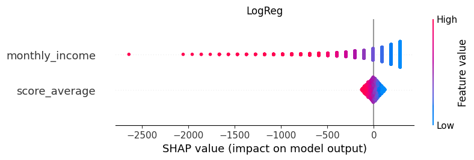

```python
explainer = shap.Explainer(lr_base_model, lr_base_dict['X_train'])
shap_values = explainer(lr_base_dict['X_test'])

shap.plots.beeswarm(shap_values, show=False)

plt.title('LogReg')
```

Also, with this simple two-parameter logistic regression model, we can directly draw the decision boundary in monthly_income -- score_average space.

```python
review_test = copy.deepcopy(lr_base_dict['X_test'])

review_test['id'] = lr_base_dict['test_ids']
review_test['prob'] = lr_base_y_proba[:, 1]
review_test['pred'] = lr_base_y_pred

col = 'monthly_income'

df1 = review_test[review_test['pred']==1]
df0 = review_test[review_test['pred']==0]
```

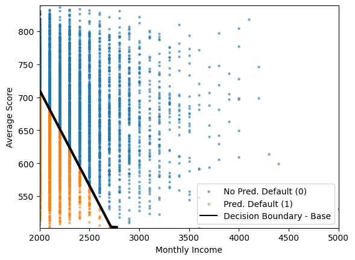

```python
plt.scatter(df0['monthly_income'], df0['score_average'], s=5, alpha=0.5, label='No Pred. Default (0)')
plt.scatter(df1['monthly_income'], df1['score_average'], s=5, alpha=0.5, label='Pred. Default (1)')



plt.tricontour(review_test['monthly_income'], review_test['score_average'], review_test['prob'], [0,0.5], linewidths=3, colors='k')
plt.plot(np.nan, np.nan, color='k', label='Decision Boundary - Base')
plt.legend()
plt.xlabel('Monthly Income')
plt.ylabel('Average Score')
```

Here we show the decision boundary as the black line, determined by leaving the probability threshold at its default values of 0.5. In terms of explainability, this model is very difficult to beat. If a customer want to know why they were denied, you can simply point out where they fall in the monthly_income -- score_average plane.

Next we will see if we can improve the performance of the model by scaling the class weights.

### Optimizing class weights

As discussed earlier, the class imbalance in the logistic regression model is handled by applying a class weight. Adjusting this weighting will alter the performance of our model. To illustrate this, we will fit our model with different class weighting and see how it affects the evaluation metrics

```python
f1_scores = []
precision_scores = []
recall_scores = []

eta_vals = np.linspace(0.5, 0.95, 20)

for eta in eta_vals:
    print(eta)
    class_weight = {0:1-eta, 1:eta}
    lr_eta_model = LogisticRegression(random_state=0,  class_weight = class_weight)
    # Fit (scaled) train data
    lr_eta_model.fit(X_train_scaled, lr_base_dict['y_train'])

    # make predictions for (scaled) test data
    lr_eta_y_pred = lr_eta_model.predict(X_test_scaled)
    lr_eta_y_proba = lr_eta_model.predict_proba(X_test_scaled)

    # evaluate predictions
    f1 = f1_score(lr_base_dict['y_test'], lr_eta_y_pred)
    recall = recall_score(lr_base_dict['y_test'], lr_eta_y_pred)
    precision = precision_score(lr_base_dict['y_test'], lr_eta_y_pred)


    f1_scores.append(f1)
    precision_scores.append(precision)
    recall_scores.append(recall)
```

```
0.5
0.5236842105263158
0.5473684210526316
0.5710526315789474
0.5947368421052631
```

```
Precision is ill-defined and being set to 0.0 due to no predicted samples. Use `zero_division` parameter to control this behavior.
Precision is ill-defined and being set to 0.0 due to no predicted samples. Use `zero_division` parameter to control this behavior.
```

```
0.618421052631579
0.6421052631578947
0.6657894736842105
0.6894736842105262
0.7131578947368421
0.7368421052631579
0.7605263157894737
0.7842105263157895
0.8078947368421052
0.831578947368421
0.8552631578947367
0.8789473684210526
0.9026315789473685
0.9263157894736842
0.95
```

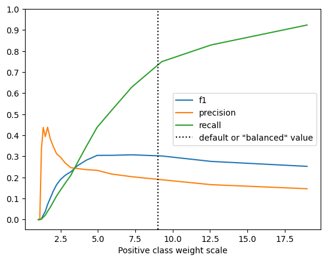

```python
plt.plot(eta_vals/(1-eta_vals), f1_scores, label='f1')
plt.plot(eta_vals/(1-eta_vals), precision_scores, label='precision')
plt.plot(eta_vals/(1-eta_vals), recall_scores, label='recall')
plt.axvline(9, ls=":", color='k', label='default or "balanced" value')
plt.legend()
plt.gca().set_yticks(np.linspace(0,1,11))
plt.xlabel('Positive class weight scale')
```

We see here that by altering the class weight we can effectively choose an arbitrary recall score. Ideally, we could determine where this should be based on business tolerance for false negatives vs false positives, which would in turn depend on potential profits or losses of the loans.

This would be an excellent value to quantify in a more in depth analysis. For now however, we could determine an appropriate recall threshold using the "elbow" method, where we see the recall curve start to turn over indicating diminishing returns. The default value is already fairly close, so we will proceed with the default "balanced" class weight and note that there may be room for some improvement here.

### Additional features

Before moving on we will briefly test how the model is affected by the inclusion of additional features. Earlier we made arguments claiming that monthly_income and average_score were sufficient for predictions, now we can test it directly.

Here we will include most of the full feature set, only removing highly correlated features

Remove uninformative (DOB, id) and correlated ( 'score1', 'score2', 'score_income_multiplier') features

```python
drop_train_cols = ['date_of_birth', 'id', 'score1', 'score2', 'target',
       'score_income_multiplier']
lr_feat_dict = get_train_test_dict(df, target_var, id_col = 'id', cols=drop_train_cols, drop=True)
lr_feat_dict['X_train'].columns
```

```
remove id_col
```

```
Index(['number_dependants', 'credit_utilization', 'debt_to_income_ratio',
       'monthly_income', 'number_open_credit_lines', 'number_open_loans',
       'number_90_days_past_due', 'number_charged_off', 'age',
       'score_average'],
      dtype='object')
```

```python
lr_feat_model = LogisticRegression(random_state=0,  class_weight = 'balanced')

print('features included:', lr_feat_dict['X_train'].columns.to_list())

# scale training data
scaler = preprocessing.StandardScaler().fit(lr_feat_dict['X_train'])

X_train_scaled = pd.DataFrame(scaler.transform(lr_feat_dict['X_train']), columns=lr_feat_dict['X_train'].columns)
X_test_scaled = pd.DataFrame(scaler.transform(lr_feat_dict['X_test']), columns=lr_feat_dict['X_test'].columns)


# Fit (scaled) train data
lr_feat_model.fit(X_train_scaled, lr_feat_dict['y_train'])

# make predictions for (scaled) test data
lr_feat_y_pred = lr_feat_model.predict(X_test_scaled)
lr_feat_y_proba = lr_feat_model.predict_proba(X_test_scaled)


# evaluate predictions
pr_fpr, pr_tpr, pr_thresholds = precision_recall_curve(lr_feat_dict['y_test'], lr_feat_y_proba[:,1])
auc_pr = auc(pr_tpr, pr_fpr)

roc_fpr, roc_tpr, roc_thresholds = roc_curve(lr_feat_dict['y_test'], lr_feat_y_proba[:,1])
roc_auc = roc_auc_score(lr_feat_dict['y_test'], lr_feat_y_pred)
f1 = f1_score(lr_feat_dict['y_test'], lr_feat_y_pred)
recall = recall_score(lr_feat_dict['y_test'], lr_feat_y_pred)
precision = precision_score(lr_feat_dict['y_test'], lr_feat_y_pred)


print("roc_auc: %.2f%%" % (roc_auc * 100.0))
print("auc_pr: %.2f%%" % (auc_pr * 100.0))
print("Recall: {:.2f}%".format(recall * 100.0))
print("Precision: {:.2f}%".format(precision * 100.0))
print("F1: {:.2f}%".format(f1 * 100.0))

print(classification_report(lr_feat_dict['y_test'], lr_feat_y_pred))
```

```
features included: ['number_dependants', 'credit_utilization', 'debt_to_income_ratio', 'monthly_income', 'number_open_credit_lines', 'number_open_loans', 'number_90_days_past_due', 'number_charged_off', 'age', 'score_average']
roc_auc: 68.45%
auc_pr: 23.00%
Recall: 72.05%
Precision: 19.06%
F1: 30.15%
              precision    recall  f1-score   support

           0       0.95      0.65      0.77      5606
           1       0.19      0.72      0.30       644

    accuracy                           0.66      6250
   macro avg       0.57      0.68      0.54      6250
weighted avg       0.87      0.66      0.72      6250
```

```python
kfold = KFold(n_splits=10, shuffle=True,random_state=seed)
results = cross_val_score(lr_feat_model, X_train_scaled, lr_feat_dict['y_train'],scoring='f1', cv=kfold)
print("K-fold f1 score: {:.2f}% ({:.2f}%)".format(results.mean()*100, results.std()*100))

results = cross_val_score(lr_feat_model, X_train_scaled, lr_feat_dict['y_train'],scoring='recall', cv=kfold)
print("K-fold recall score: {:.2f}% ({:.2f}%)".format(results.mean()*100, results.std()*100))

results = cross_val_score(lr_feat_model, X_train_scaled, lr_feat_dict['y_train'],scoring='precision', cv=kfold)
print("K-fold precision score: {:.2f}% ({:.2f}%)".format(results.mean()*100, results.std()*100))
```

```
K-fold f1 score: 30.44% (2.50%)
K-fold recall score: 72.30% (4.36%)
K-fold precision score: 19.32% (1.86%)
```

```python
coeff_dict = dict(zip(lr_feat_dict['X_train'].columns, list((lr_feat_model.coef_[0]))))
coeff_dict =  dict(sorted(coeff_dict.items(), key=lambda item: item[1]))

for key in coeff_dict.keys():
    coeff = coeff_dict[key]

    #TODO fix Calculation
    odds = np.exp(coeff)
    print( '{} coeff: {:.2f} odds ratio: {:.2f}' .format(key, coeff_dict[key],odds))
```

```
monthly_income coeff: -0.98 odds ratio: 0.38
score_average coeff: -0.75 odds ratio: 0.47
credit_utilization coeff: -0.04 odds ratio: 0.96
number_open_loans coeff: -0.03 odds ratio: 0.97
number_charged_off coeff: -0.03 odds ratio: 0.97
number_90_days_past_due coeff: -0.02 odds ratio: 0.98
number_dependants coeff: 0.00 odds ratio: 1.00
age coeff: 0.01 odds ratio: 1.01
debt_to_income_ratio coeff: 0.02 odds ratio: 1.02
number_open_credit_lines coeff: 0.04 odds ratio: 1.04
```

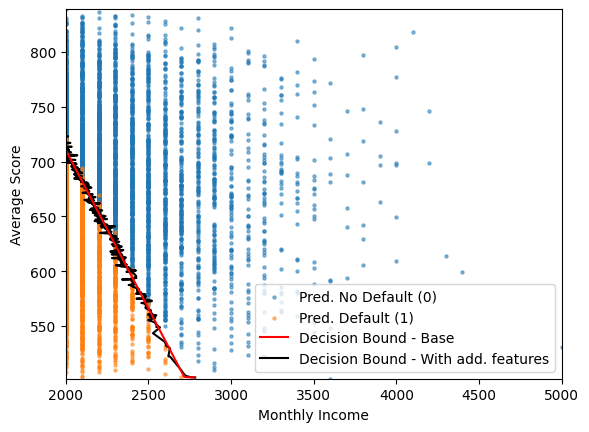

```python
review_test_feat = copy.deepcopy(lr_feat_dict['X_test'])

review_test_feat['id'] = lr_feat_dict['test_ids']
review_test_feat['prob'] = lr_feat_y_proba[:, 1]
review_test_feat['pred'] = lr_feat_y_pred

col = 'monthly_income'

df1 = review_test_feat[review_test_feat['pred']==1]
df0 = review_test_feat[review_test_feat['pred']==0]



plt.scatter(df0['monthly_income'], df0['score_average'], s=5, alpha=0.5, label='Pred. No Default (0)')
plt.scatter(df1['monthly_income'], df1['score_average'], s=5, alpha=0.5, label='Pred. Default (1)')

plt.tricontour(review_test_feat['monthly_income'], review_test_feat['score_average'], review_test_feat['prob'], [0,0.5], linewidths=1.5, colors='k')
plt.tricontour(review_test['monthly_income'], review_test['score_average'], review_test['prob'], [0,0.5], linewidths=1.5, colors='r')

plt.plot(np.nan, np.nan, color='r', label='Decision Bound - Base')
plt.plot(np.nan, np.nan, color='k', label='Decision Bound - With add. features')

plt.legend()
plt.xlabel('Monthly Income')
plt.ylabel('Average Score')
```

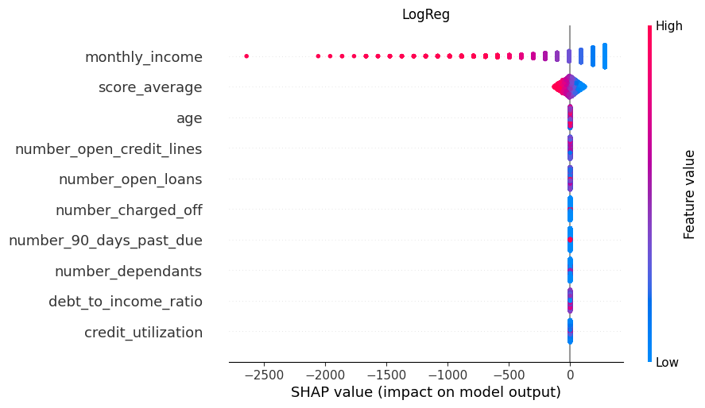

```python
explainer = shap.Explainer(lr_feat_model, lr_feat_dict['X_train'])
shap_values = explainer(lr_feat_dict['X_test'])

shap.plots.beeswarm(shap_values, show=False)

plt.title('LogReg')
```

As can be seen above, the model is minimally affected by the inclusion of additional independent features. This is reflected in the evaluation metrics, coefficients, SHAP values, and is also visually apparent when drawing the decision boundary in monthly_income -- score_average space.

We can conclude that the inclusion of the additional features does not add performance improvements and only serves to complicate the model

### Logistic Regression Summary

We constructed a very simple Logistic regression model using only two parameters: monthly_income and score_average. While the model does not perform well in terms of precision or F1, recall is decent at ~72%. A major benefit of this model is its simplicity and interpretability - it can be explicitly explained why a customer would be considered a default risk based on the two parameters used.

The model could further be optimized for either recall or another more appropriate metric (e.g. an $F_{\beta}$ score) by adjusting the class-weighting.

We also saw that adding additional independent features does not improve the model, and thus adding complexity to the model is not worthwhile.

## XGBoost Classifier

The next model we will test is a classifier using XGBoost. Here we will keep most of the features, removing only uninformative or correlated features. This model is fairly robust to the feature selection, and we do not interpret model coefficients directly as we do in the logistic regression, so we will not spend much time testing out multiple selection. Optimizing the feature selection could potentially improve the model.

As we did for the logistic regression model, we will use a class weighting to address the class imbalance, here implemented by setting the xgboost scale_pos_weight parameter to the majority-minority class ratio which is ~9

Given the unbalanced data, we use the AUC-PR as the evaluation metric when fitting the XGBoost classifier.

```python
seed=0
target_var  =  'target'

drop_train_cols = ['date_of_birth', 'id']
drop_train_cols = ['date_of_birth', 'id', 'score1', 'score2', 'target', 'score_income_multiplier']
xgb_dict = get_train_test_dict(df, target_var, id_col = 'id', cols=drop_train_cols, drop=True)
#keep_train_cols = ['monthly_income', 'score_average']
#xgb_dict = get_train_test_dict(df, target_var, id_col = 'id', cols=keep_train_cols, drop=False)
xgb_dict['X_train']
```

```
remove id_col
```

|  | number_dependants | credit_utilization | debt_to_income_ratio | monthly_income | number_open_credit_lines | number_open_loans | number_90_days_past_due | number_charged_off | age | score_average |
| --- | --- | --- | --- | --- | --- | --- | --- | --- | --- | --- |
| 6342 | 0 | 0.046453 | 0.242645 | 2000 | 3 | 1 | 0 | 0 | 62 | 709.0 |
| 977 | 0 | 0.090836 | 0.243761 | 2700 | 9 | 2 | 0 | 1 | 87 | 556.5 |
| 11172 | 0 | 0.067976 | 0.209619 | 2300 | 5 | 1 | 0 | 0 | 58 | 795.5 |
| 6934 | 1 | 0.156632 | 0.486520 | 2100 | 5 | 1 | 0 | 0 | 60 | 553.5 |
| 8903 | 0 | 0.013837 | 0.417057 | 2000 | 5 | 2 | 0 | 0 | 36 | 777.5 |
| ... | ... | ... | ... | ... | ... | ... | ... | ... | ... | ... |
| 13128 | 0 | 0.015057 | 0.230730 | 2000 | 4 | 0 | 0 | 0 | 79 | 702.0 |
| 19654 | 0 | 0.107423 | 0.323088 | 2000 | 6 | 2 | 0 | 0 | 73 | 747.5 |
| 9849 | 0 | 0.057702 | 0.338929 | 2000 | 3 | 3 | 0 | 0 | 89 | 762.0 |
| 10803 | 0 | 0.127954 | 0.115117 | 2500 | 2 | 2 | 0 | 0 | 72 | 598.0 |
| 2734 | 1 | 0.038035 | 0.205415 | 2600 | 8 | 2 | 0 | 0 | 45 | 648.0 |

14582 rows × 10 columns

```python
# Here we will define our first baseline version of the model, using mainly default parameters
# scale_pos_weight is modified to account for class imbalance

scale_pos_weight = 9 #since there is a ~9/1 ratio of majority - minority records
seed = 0

xgb_model = xgb.XGBClassifier(scale_pos_weight = scale_pos_weight, seed=seed,random_state=seed, eval_metric='aucpr')

xgb_model.fit(xgb_dict['X_train'], xgb_dict['y_train'], eval_set=xgb_dict['eval_set'], verbose=False)


# make predictions for test data
xgb_y_pred = xgb_model.predict(xgb_dict['X_test'])


# evaluate predictions
fpr, tpr, thresholds = precision_recall_curve(xgb_dict['y_test'], xgb_y_pred, pos_label=1)
auc_pr = auc(fpr, tpr)
roc_auc = roc_auc_score(xgb_dict['y_test'], xgb_y_pred)
f1= f1_score(xgb_dict['y_test'], xgb_y_pred)
recall= recall_score(xgb_dict['y_test'], xgb_y_pred)
precision= precision_score(xgb_dict['y_test'], xgb_y_pred)

print("roc_auc: %.2f%%" % (roc_auc * 100.0))
print("auc_pr: %.2f%%" % (auc_pr * 100.0))
print("Recall: {:.2f}%".format(recall * 100.0))
print("Precision: {:.2f}%".format(precision * 100.0))
print("F1: {:.2f}%".format(f1 * 100.0))
```

```
roc_auc: 60.41%
auc_pr: 22.19%
Recall: 38.82%
Precision: 19.86%
F1: 26.27%
```

```python
kfold = KFold(n_splits=10, shuffle=True,random_state=0)
results = cross_val_score(xgb_model, xgb_dict['X_train'], xgb_dict['y_train'],scoring='f1', cv=kfold)
print("K-fold f1 score: {:.2f}% ({:.2f}%)".format(results.mean()*100, results.std()*100))
results = cross_val_score(xgb_model, xgb_dict['X_train'], xgb_dict['y_train'],scoring='recall', cv=kfold)
print("K-fold recall score: {:.2f}% ({:.2f}%)".format(results.mean()*100, results.std()*100))
results = cross_val_score(xgb_model, xgb_dict['X_train'], xgb_dict['y_train'],scoring='precision', cv=kfold)
print("K-fold precision score: {:.2f}% ({:.2f}%)".format(results.mean()*100, results.std()*100))
```

```
K-fold f1 score: 24.58% (2.15%)
K-fold recall score: 34.82% (3.19%)
K-fold precision score: 19.10% (2.17%)
```

### Initial Results

We can see that in the initial model all of our evaluation metrics are poor. Recall in particular is much worse than the logistic regression model. However, we can improve the model performance with hyperparameter tuning as we will do in the next section.

```
              precision    recall  f1-score   support

           0       0.92      0.82      0.87      5606
           1       0.20      0.39      0.26       644

    accuracy                           0.78      6250
   macro avg       0.56      0.60      0.57      6250
weighted avg       0.85      0.78      0.81      6250
```

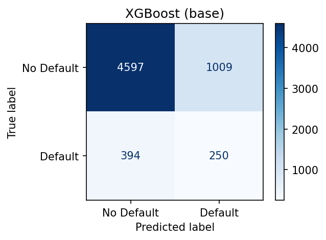

```python
plt.figure(figsize=(4,3), dpi=150)
ax = plt.gca()
# Compute values for confusion matrix
log_cm = confusion_matrix(xgb_dict['y_test'], xgb_y_pred)

# Create display of confusion matrix
log_disp = ConfusionMatrixDisplay(confusion_matrix=log_cm, display_labels=['No Default', 'Default'])
log_disp.plot(cmap='Blues',ax=ax)

ax.set_title('XGBoost (base)')

print(classification_report(xgb_dict['y_test'], xgb_y_pred))
```

**Learning Curves**

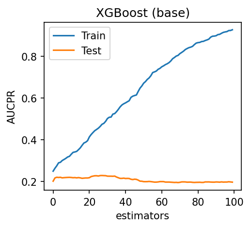

```python
#Here we can check learning cruves for our model using aucpr
results_pre_opt = xgb_model.evals_result()

plt.figure(figsize=(3.5, 3), dpi=150)
# plot learning curves
plt.plot(results_pre_opt['validation_0']['aucpr'], label='Train')
plt.plot(results_pre_opt['validation_1']['aucpr'], label='Test')
plt.ylabel('AUCPR')
plt.xlabel('estimators')
plt.legend()
plt.title('XGBoost (base)')
```

Looking at the initial learning curves from the base XGBoost model, we see that it is performing very poorly. For the test set, the curve is mostly flat with a general downward trend, while the training curve is consistently increasing. This is far from desired behaviors and indicates our model will not generalize well. However, we can hopefully fix this with hyperparameter tuning.

### Hyperparameter Tuning

For the hyperparameter tuning, we will stick to some of the basic parameters, such as max_depth, learning_rate, and n_estimators. Since recall is our primary metric of interest, we will optimize recall.

Another parameter we could potentially tune is scale_pos_weight, which weights the positive class (default) relative to the negative class (no default). As a rule of thumb this values for unbalanced datsets can be set to the ratio of the majority class to the minority class. As with the logistic regression model, this is potentiall opportunity to improve model performance, however modification of the class weighting should be done carefully and with reliable motivation.

```python
hyp_params = {
    'max_depth': hp.choice('max_depth', np.arange(1, 10, dtype=int)),
    'learning_rate': hp.loguniform('learning_rate', -3, 0.1),
    'n_estimators': hp.choice('n_estimators', np.arange(10, 300, dtype=int)),
    #'scale_pos_weight' : hp.uniform('scale_pos_weight', 5, 12)
}
```

```python
# An objective function is needed for the hyperopt tuning
def objective(hyp_params):
    clf=xgb.XGBClassifier(scale_pos_weight=9, seed=seed,random_state=seed,eval_metric='aucpr', **hyp_params)

    evaluation = xgb_dict['eval_set']

    clf.fit(xgb_dict['X_train'], xgb_dict['y_train'],
            eval_set=evaluation,  verbose=False)

    pred = clf.predict(xgb_dict['X_test'])

    recall_clf = recall_score(xgb_dict['y_test'], pred)
    print("Recall SCORE: {:.1f}%".format( recall_clf*100))
    print(hyp_params, '\n\n')

    return {'loss': -recall_clf, 'status': STATUS_OK }
```

```python
#best_params = {'learning_rate': 0.32613322505015735,
# 'max_depth': 1,
# 'n_estimators': 43,
# 'scale_pos_weight': 11.999695710217374}
```

```python
%%time

print("finding best hyperparams")
trials = Trials()
best_params = fmin(objective, hyp_params, algo=tpe.suggest, max_evals=100, trials=trials, return_argmin=False, rstate = np.random.default_rng(seed))
print("Best set of hyperparameters: ", best_params)
```

```
finding best hyperparams
Recall SCORE: 57.8%
{'learning_rate': 0.08954030922241034, 'max_depth': 7, 'n_estimators': 113}
Recall SCORE: 31.8%
{'learning_rate': 0.11704553756518427, 'max_depth': 8, 'n_estimators': 154}
Recall SCORE: 48.0%
{'learning_rate': 0.4398535736694678, 'max_depth': 4, 'n_estimators': 176}
Recall SCORE: 51.6%
{'learning_rate': 0.13215139914816137, 'max_depth': 9, 'n_estimators': 45}
Recall SCORE: 45.7%
{'learning_rate': 0.8800853037538393, 'max_depth': 5, 'n_estimators': 41}
Recall SCORE: 18.0%
{'learning_rate': 0.3432145749034329, 'max_depth': 9, 'n_estimators': 85}
Recall SCORE: 13.7%
{'learning_rate': 1.072460458201217, 'max_depth': 7, 'n_estimators': 272}
Recall SCORE: 77.3%
{'learning_rate': 0.055291387197299015, 'max_depth': 2, 'n_estimators': 99}
Recall SCORE: 75.8%
{'learning_rate': 0.06771540446456838, 'max_depth': 5, 'n_estimators': 12}
Recall SCORE: 59.3%
{'learning_rate': 0.23193114400056974, 'max_depth': 4, 'n_estimators': 199}
Recall SCORE: 58.1%
{'learning_rate': 0.224544326990115, 'max_depth': 4, 'n_estimators': 219}
Recall SCORE: 38.2%
{'learning_rate': 0.27871592970141734, 'max_depth': 6, 'n_estimators': 131}
Recall SCORE: 16.5%
{'learning_rate': 0.8891142388606061, 'max_depth': 6, 'n_estimators': 168}
Recall SCORE: 12.4%
{'learning_rate': 0.6018322496159735, 'max_depth': 8, 'n_estimators': 205}
Recall SCORE: 41.6%
{'learning_rate': 0.9488853525802273, 'max_depth': 6, 'n_estimators': 29}
Recall SCORE: 19.6%
{'learning_rate': 0.3381862694167717, 'max_depth': 6, 'n_estimators': 278}
Recall SCORE: 77.8%
{'learning_rate': 0.1677349201366436, 'max_depth': 1, 'n_estimators': 274}
Recall SCORE: 70.2%
{'learning_rate': 0.1314695048034014, 'max_depth': 3, 'n_estimators': 261}
Recall SCORE: 11.8%
{'learning_rate': 0.6741064829190943, 'max_depth': 8, 'n_estimators': 128}
Recall SCORE: 65.2%
```

[output cut: 149 more lines]

```
Recall SCORE: 75.6%
{'learning_rate': 0.050175906096786536, 'max_depth': 4, 'n_estimators': 86}
Recall SCORE: 78.3%
{'learning_rate': 0.10434813269085623, 'max_depth': 1, 'n_estimators': 241}
Recall SCORE: 76.9%
{'learning_rate': 0.07927950607955792, 'max_depth': 2, 'n_estimators': 147}
Recall SCORE: 20.2%
{'learning_rate': 0.14883099232410887, 'max_depth': 8, 'n_estimators': 230}
Recall SCORE: 70.5%
{'learning_rate': 0.11816012455603639, 'max_depth': 7, 'n_estimators': 22}
Recall SCORE: 69.7%
{'learning_rate': 0.05856620034208548, 'max_depth': 5, 'n_estimators': 174}
Best set of hyperparameters:  {'learning_rate': 0.10726980314505748, 'max_depth': 1, 'n_estimators': 71}
CPU times: user 4min 17s, sys: 1.2 s, total: 4min 18s
Wall time: 3min 33s
```

```
roc_auc: 68.71%
auc_pr: 39.48%
Recall: 79.66%
Precision: 17.81%
F1: 29.11%
```

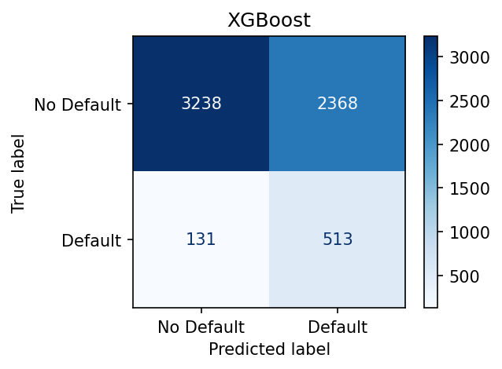

```python
#model_HT is the Hypertuned model

model_HT = xgb.XGBClassifier( scale_pos_weight=9, seed=seed, eval_metric='aucpr',  **best_params)

model_HT.fit(xgb_dict['X_train'], xgb_dict['y_train'], eval_set=xgb_dict['eval_set'], verbose=False)

# make predictions for test data
y_pred = model_HT.predict(xgb_dict['X_test'])

# evaluate predictions
fpr, tpr, thresholds = precision_recall_curve(xgb_dict['y_test'], y_pred, pos_label=1)
auc_pr = auc(fpr, tpr)
roc_auc = roc_auc_score(xgb_dict['y_test'], y_pred)

f1_HT = f1_score(xgb_dict['y_test'], y_pred)
recall_HT = recall_score(xgb_dict['y_test'], y_pred)
precision_HT = precision_score(xgb_dict['y_test'], y_pred)




print("roc_auc: %.2f%%" % (roc_auc * 100.0))
print("auc_pr: %.2f%%" % (auc_pr * 100.0))
print("Recall: {:.2f}%".format(recall_HT * 100.0))
print("Precision: {:.2f}%".format(precision_HT * 100.0))
print("F1: {:.2f}%".format(f1_HT * 100.0))

plt.figure(figsize=(4,3), dpi=150)
ax = plt.gca()

# Compute values for confusion matrix
log_cm = confusion_matrix(xgb_dict['y_test'], y_pred)

# Create display of confusion matrix
log_disp = ConfusionMatrixDisplay(confusion_matrix=log_cm, display_labels=["No Default", "Default"])

log_disp.plot(cmap='Blues',ax=ax)
ax.set_title('XGBoost')
```

```python
kfold = KFold(n_splits=10, shuffle=True,random_state=0)
results = cross_val_score(model_HT, xgb_dict['X_train'], xgb_dict['y_train'],scoring='f1', cv=kfold)
print("K-fold f1 score: {:.2f}% ({:.2f}%)".format(results.mean()*100, results.std()*100))

results = cross_val_score(model_HT, xgb_dict['X_train'], xgb_dict['y_train'],scoring='recall', cv=kfold)
print("K-fold recall score: {:.2f}% ({:.2f}%)".format(results.mean()*100, results.std()*100))

results = cross_val_score(model_HT, xgb_dict['X_train'], xgb_dict['y_train'],scoring='precision', cv=kfold)
print("K-fold precision score: {:.2f}% ({:.2f}%)".format(results.mean()*100, results.std()*100))
```

```
K-fold f1 score: 29.39% (2.45%)
K-fold recall score: 77.63% (3.17%)
K-fold precision score: 18.16% (1.79%)
```

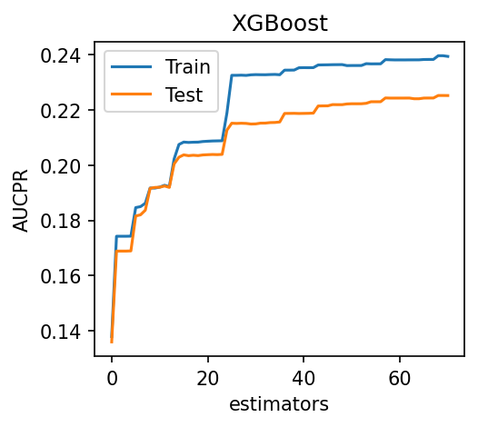

```python
#Here we can check learning cruves for our model using aucpr
results_pre_opt = model_HT.evals_result()

plt.figure(figsize=(3.5, 3), dpi=150)
# plot learning curves
plt.plot(results_pre_opt['validation_0']['aucpr'], label='Train')
plt.plot(results_pre_opt['validation_1']['aucpr'], label='Test')
plt.ylabel('AUCPR')
plt.xlabel('estimators')
plt.title('XGBoost')
plt.legend()
```

Here we see that the hyperparameter tuned model performance is much better than the base XGBoost model. In terms of recall, the final XGBoost model outperforms the logistic regression model with 78% recall compared to 72% (though it is slightly worse in terms of precison and F1).

The learning curves are also much improved compared to the base XGBoost model

### Feature importances and SHAP Values

For the XGBoost model, we do not have coefficients for interpretation as we did in the logistic regression model. Instead we look to the feature importances. Below we show both the Gain importance and the F-score/weight importance from the hyperparameter tuned model. We see that the model really only cares about the monthly_income and score_average, similar to the logistic regression model.

Also, we can view the SHAP values which tell effectively the same story.

[figure not shown]

```python
fig, ax = plt.subplots(1,2,figsize=(18,10))
# plot feature importance
xgb.plot_importance(model_HT, max_num_features=None,ax=ax[0], ylabel=None,title='Feature importance - Gain - XGBoost', grid=False, importance_type='gain', values_format = "{v:.1f}")
ax[0].tick_params(axis='both', which='major', labelsize=10)
ax[0].tick_params(axis='both', which='minor', labelsize=10)
ax[0].set_xlabel('Gain')
ax[0].set_yticklabels(ax[0].get_yticklabels(), rotation=45)
ax[0].spines['top'].set_visible(False)
ax[0].spines['right'].set_visible(False)


xgb.plot_importance(model_HT, ax=ax[1], ylabel=None,title='Feature importance - F score - XGBoost', grid=False,  values_format = "{v:.1f}")
ax[1].tick_params(axis='both', which='major', labelsize=10)
ax[1].tick_params(axis='both', which='minor', labelsize=10)
ax[1].set_yticklabels(ax[1].get_yticklabels(), rotation=45)
ax[1].spines['top'].set_visible(False)
ax[1].spines['right'].set_visible(False)
#plt.savefig('feat_import_F.png', facecolor='white', transparent=False)
```

```
[21:44:55] WARNING: /workspace/src/c_api/c_api.cc:1240: Saving into deprecated binary model format, please consider using `json` or `ubj`. Model format will default to JSON in XGBoost 2.2 if not specified.
```

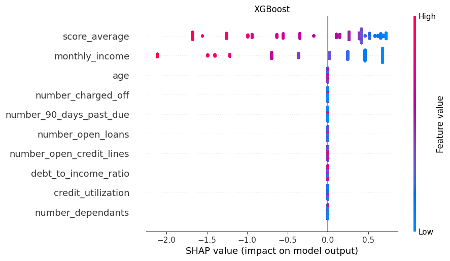

```python
explainer = shap.Explainer(model_HT, xgb_dict['X_train'])
shap_values = explainer(xgb_dict['X_test'])

shap.plots.beeswarm(shap_values, show=False)

plt.title('XGBoost')
```

### XGBoost Summary

Our XGBoost classifier model yields a recall of 78%. This is a noticeable improvement over the logistic regression model. Here we have used more features than the logistic regression model, however they do not impact the model based on feature importances and SHAP values. Our model still is easily explained by the monthly_income and score_average parameters.

## Modeling Results

We now have two models, an XGBoost classifier with hyperparameter tuning (model_HT) and two-parameter logistic regression model (lr_base_model).

The XGBoost model offer better recall, at ~78% vs ~72% for the logistic regression model. The logistic regression model slightly outperforms in terms of the F1 and precision scores.

The logistic regression model stands out for its simplicity and explainability. However, given the potential costs of False Negative (FN) classifications (i.e. we loan to someone that defaults), the improved recall of the XGBoost classifier model is worth the additional complexity. Even with the XGBoost classifier, our model can be fairly easily explained based on monthly_income and score_average as interpreted from feature importances and SHAP values.